# Analyzing multivariate data

Oscar Feng-Hsun Chang

27 December, 2020

# 1 Multivariate analysis

- Nature, and thus the ecological data, are multidimensional.
- A method to summarize redundancy, i.e., reduce the dimension, of ecological data.
- A method to detect and quantify an underlying trends shared by multiple variables

# 2 Types of linear models

## 2.1 Single dependent variable ($Y$) + single or multiple independent variable ($X$)

- linear regression
- ANOVA
- Contingency table, e.g. $\chi^2$ test

## 2.2 multiple dependent variable ($Y$)

- Ordination, e.g., principle component analysis (PCA), canonical analysis (CA), non-metric multidimensional scaling (NMDS)
- cluster analysis, e.g., K-means, K-medoids

## 2.3 multiple dependent variable ($Y$) + single independent variable ($X$)

- Multivariate ANOVA (MANOVA)
- Discriminant analysis

## 2.4 multiple dependent variable ($Y$) + multiple independent variable ($X$)

- Redundancy analysis (RDA)
- Canonical correspondence analysis (CCA)

# 3 Examples

Data is from my field work.

[figure not shown]

- Environmental data for each lake

```r
Field.raw <- read.table(file = "https://raw.githubusercontent.com/OscarFHC/OmniBEF_FieldNLA_public/master/FieldDat_raw.csv",
                        sep = ",", header = TRUE)
head(Field.raw[, c(4:6, 8:10)])
```

```
##     pH  Cond Temp       PAR  TN_mean  TP_mean
## 1 8.33 408.8 21.9 0.5600000 20.68208 23.75631
## 2 8.61 257.7 20.8 0.6416667 63.02927 24.27327
## 3 8.19 358.7 20.6 0.4730539 40.83156 15.87882
## 4 8.23 314.8 24.5 0.3636364 28.14599 15.26339
## 5 8.30 256.3 26.4 0.3529412 37.36898 16.66657
## 6 8.58  93.9 27.6 0.6393443 52.13870 15.53418
```

- Zooplankton species composition: site by species in density (ind./ml) table

```r
zp.raw <- read.table(file = "https://raw.githubusercontent.com/OscarFHC/Multidimension/main/Data/Field_zpComm.csv",
                        sep = ",", header = TRUE)
zp <- zp.raw[,2:52]
head(zp[,1:10])
```

```
##     X83936   X125923     X59270    X59074   X58633   X125904   X83971    X88634
## 1 12.92776  12.92776   12.92776  25.85552 12.92776  12.92776 12.92776  77.56657
## 2 20.52576 143.68032  759.45310 431.04095  0.00000   0.00000  0.00000 184.73183
## 3  0.00000  33.89607  101.68822   0.00000  0.00000   0.00000  0.00000 271.16858
## 4  0.00000 173.96746  154.63775  19.32972  0.00000   0.00000  0.00000 135.30803
## 5  0.00000   0.00000 1442.30769   0.00000  0.00000 346.15385  0.00000 403.84615
## 6  0.00000   0.00000  234.91797   0.00000  0.00000   0.00000  0.00000 249.60034
##     X88599     aaaaa
## 1 25.85552  38.78329
## 2  0.00000 513.14398
## 3  0.00000  33.89607
## 4 19.32972 212.62690
## 5  0.00000 692.30769
## 6 14.68237 499.20069
```

## 3.1 multiple dependent variable ($Y$)

- Ordination, e.g., principle component analysis (PCA), canonical analysis (CA), non-metric multidimensional scaling (NMDS)
- cluster analysis, e.g., K-means, K-medoids

### 3.1.1 PCA

#### 3.1.1.1 PCA by environmental variables

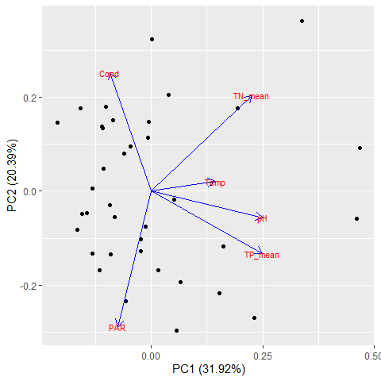

```r
envi <- as.data.frame(scale(Field.raw[, c(4:6, 8:10)], center = TRUE, scale = TRUE))
enviPCA <- prcomp(envi)
autoplot(enviPCA, loadings = TRUE, loadings.colour = 'blue',
         loadings.label = TRUE, loadings.label.size = 3)
```

#### 3.1.1.2 PCA by zooplankton spcies

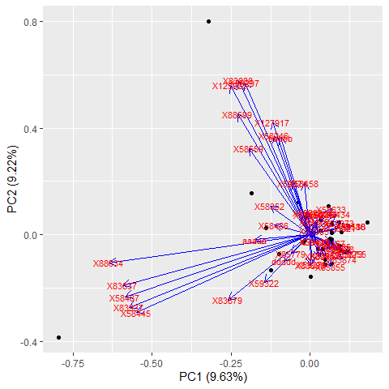

```r
zp <- as.data.frame(scale(zp, center = TRUE, scale = TRUE))
spPCA <- prcomp(zp)
autoplot(spPCA, loadings = TRUE, loadings.colour = 'blue',
         loadings.label = TRUE, loadings.label.size = 3)
```

#### 3.1.1.3 NMDS by environmental variables

There is no “variation explained” in NMDS.

```r
enviNMDS <- metaMDS(Field.raw[, c(4:6, 8:10)], k=2, trymax=100)
```

```
## Square root transformation
## Wisconsin double standardization
## *** Solution reached
```

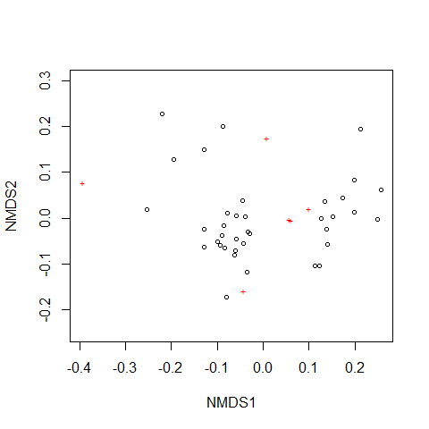

```r
plot(enviNMDS)
```

### 3.1.2 K-means

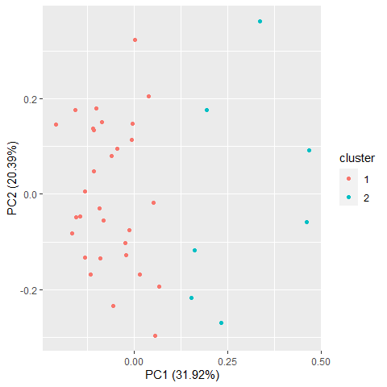

```r
set.seed(1032)
autoplot(kmeans(envi, 2), data = envi)
```

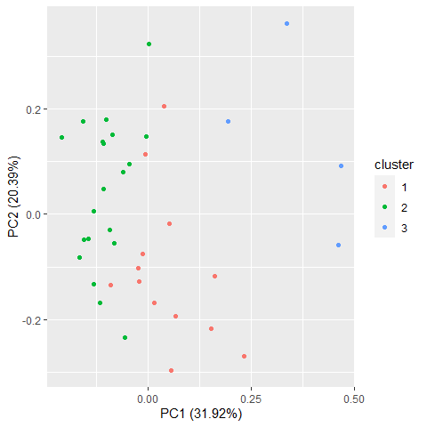

```r
autoplot(kmeans(envi, 3), data = envi)
```

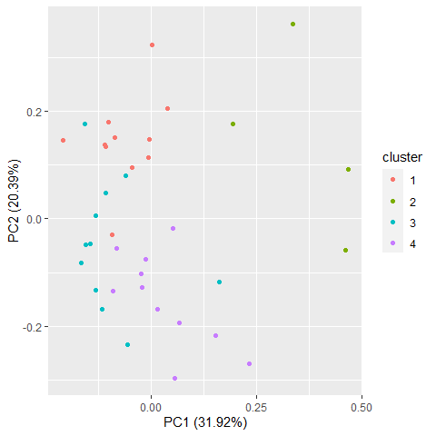

```r
autoplot(kmeans(envi, 4), data = envi)
```

**Within group variation** (total within sum of square) to determine the number of cluster

```r
set.seed(1032)
envik2 <- kmeans(envi, 2)
envik2
```

```
## K-means clustering with 2 clusters of sizes 30, 7
##
## Cluster means:
##           pH        Cond        Temp        PAR    TN_mean    TP_mean
## 1 -0.3600142  0.04709678 -0.09000433  0.0656248 -0.2638636 -0.3453918
## 2  1.5429182 -0.20184332  0.38573282 -0.2812492  1.1308438  1.4802506
##
## Clustering vector:
##  [1] 1 1 1 1 1 1 1 2 1 1 1 1 1 1 1 1 2 2 2 2 1 2 1 2 1 1 1 1 1 1 1 1 1 1 1 1 1
##
## Within cluster sum of squares by cluster:
## [1] 113.05359  50.11751
##  (between_SS / total_SS =  24.5 %)
##
## Available components:
##
## [1] "cluster"      "centers"      "totss"        "withinss"     "tot.withinss"
## [6] "betweenss"    "size"         "iter"         "ifault"
```

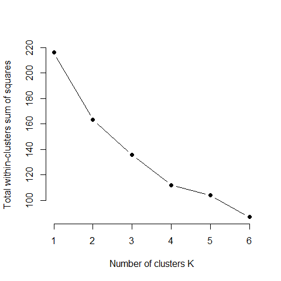

```r
set.seed(1032)
wss <- function(k) {
  kmeans(df, k, nstart = 10 )$tot.withinss
}

wss <- c()
for (i in 1:ncol(envi)){
  kn <- kmeans(envi, i)
  wss <- c(wss, kn$tot.withinss)
}

plot(wss ~ c(1:ncol(envi)),
     type="b", pch = 19, frame = FALSE,
     xlab="Number of clusters K",
     ylab="Total within-clusters sum of squares")
```

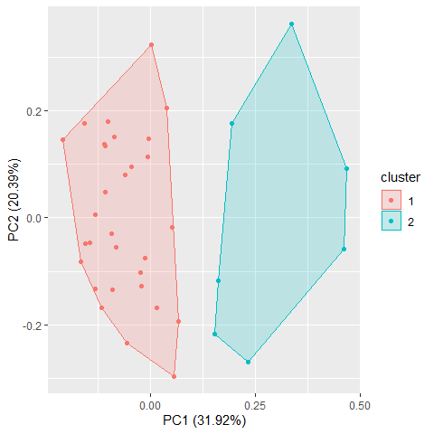

```r
set.seed(1032)
autoplot(kmeans(envi, 2), data = envi, frame = TRUE)
```

### 3.1.3 K-medoids

minimizes a sum of dissimilarities instead of a sum of squared

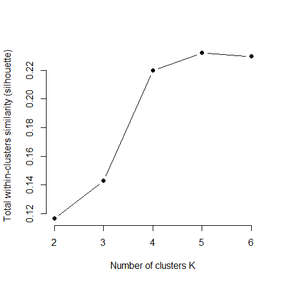

```r
set.seed(1032)

width <- c()
for (i in 1:ncol(envi)){
  width <- c(width, pam(envi, i)$silinfo$avg.width)
}

plot(width ~ c(2:ncol(envi)),
     type="b", pch = 19, frame = FALSE,
     xlab="Number of clusters K",
     ylab="Total within-clusters similarity (silhouette)")
```

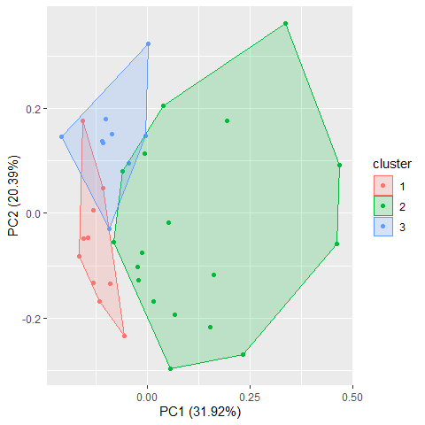

```r
set.seed(1032)
autoplot(pam(envi, 3), frame = TRUE)
```

## multiple dependent variable ($Y$) + single independent variable ($X$) - Multivariate ANOVA (MANOVA) - Discriminant analysis

### 3.1.4 Multivariate ANOVA (MANOVA)

Add `group` to indicate the grouping number

```r
set.seed(1032)
envi_K3 <- pam(envi, 3)

envi <- envi %>% mutate(group = envi_K3$clustering)

head(envi)
```

```
##            pH        Cond         Temp        PAR     TN_mean     TP_mean group
## 1 -0.68021921 -0.01345254 -1.307179826  0.8414573 -0.68395332  0.26019313     1
## 2 -0.08250326 -1.09404327 -1.859528444  1.2574495 -0.04676913  0.28624607     1
## 3 -0.97907719 -0.37174239 -1.959955466  0.3985727 -0.38077078 -0.13680408     1
## 4 -0.89368919 -0.68569297 -0.001628546 -0.1587763 -0.57164636 -0.16781949     2
## 5 -0.74426021 -1.10405536  0.952428158 -0.2132553 -0.43287098 -0.09710436     2
## 6 -0.14654426 -2.26545798  1.554990287  1.2456197 -0.21063593 -0.15417271     2
```

Perform MANOVA to test grouping significance

```r
envi_MAN <- manova(cbind(pH, Cond, Temp, PAR, TN_mean, TP_mean) ~ group, data = envi)
summary(envi_MAN)
```

```
##           Df  Pillai approx F num Df den Df    Pr(>F)
## group      1 0.75855   15.709      6     30 4.499e-08 ***
## Residuals 35
## ---
## Signif. codes:  0 '***' 0.001 '**' 0.01 '*' 0.05 '.' 0.1 ' ' 1
```

Look for the variable(s) that is different among group

```r
summary.aov(envi_MAN)
```

```
##  Response pH :
##             Df Sum Sq Mean Sq F value Pr(>F)
## group        1  0.203 0.20269  0.1982 0.6589
## Residuals   35 35.797 1.02278
##
##  Response Cond :
##             Df Sum Sq Mean Sq F value Pr(>F)
## group        1  0.822 0.82202  0.8179  0.372
## Residuals   35 35.178 1.00509
##
##  Response Temp :
##             Df Sum Sq Mean Sq F value Pr(>F)
## group        1  1.668 1.66799  1.7004 0.2007
## Residuals   35 34.332 0.98091
##
##  Response PAR :
##             Df Sum Sq Mean Sq F value    Pr(>F)
## group        1 19.579 19.5789  41.731 1.923e-07 ***
## Residuals   35 16.421  0.4692
## ---
## Signif. codes:  0 '***' 0.001 '**' 0.01 '*' 0.05 '.' 0.1 ' ' 1
##
##  Response TN_mean :
##             Df Sum Sq Mean Sq F value Pr(>F)
## group        1  0.202 0.20186  0.1974 0.6596
## Residuals   35 35.798 1.02280
##
##  Response TP_mean :
##             Df Sum Sq Mean Sq F value Pr(>F)
## group        1    2.3 2.30045  2.3892 0.1312
## Residuals   35   33.7 0.96284
```

### 3.1.5 Discriminant analysis

To find a linear combination of features that characterizes or separates two or more classes of objects or events

```r
envi_LDA <- lda(group ~ pH + Cond + Temp + PAR + TN_mean + TP_mean, data = envi)
envi_LDA
```

```
## Call:
## lda(group ~ pH + Cond + Temp + PAR + TN_mean + TP_mean, data = envi)
##
## Prior probabilities of groups:
##         1         2         3
## 0.2702703 0.4864865 0.2432432
##
## Group means:
##           pH       Cond       Temp         PAR    TN_mean    TP_mean
## 1 -0.4838268  0.5058889 -0.8753436  0.92621912 -0.3813532 -0.1448050
## 2  0.4286387 -0.3426994  0.6600739  0.04162149  0.3150043  0.5279240
## 3 -0.3196921  0.1232999 -0.3475438 -1.11237534 -0.2062828 -0.8949537
##
## Coefficients of linear discriminants:
##                 LD1        LD2
## pH       0.57405055 -0.3758025
## Cond    -0.41165484  0.4236530
## Temp    -0.03548875 -1.2226172
## PAR     -1.77297270  0.2322527
## TN_mean -0.32741994 -0.0627681
## TP_mean -1.19627528 -0.5038526
##
## Proportion of trace:
##   LD1   LD2
## 0.606 0.394
```

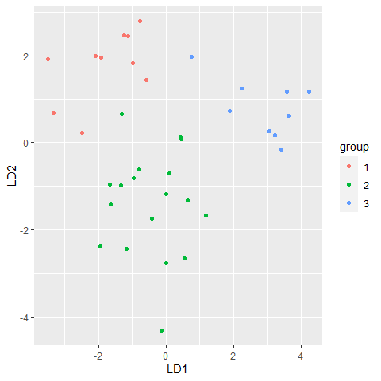

```r
cbind(envi, predict(envi_LDA)$x) %>%
  ggplot(aes(LD1, LD2, color = as.factor(group))) +
  geom_point() +
  labs(color = "group")
```

## 3.2 multiple dependent variable ($Y$) + multiple independent variable ($X$)

- Redundancy analysis (RDA)
- Canonical correspondence analysis (CCA)

### 3.2.1 Redundancy analysis (RDA)

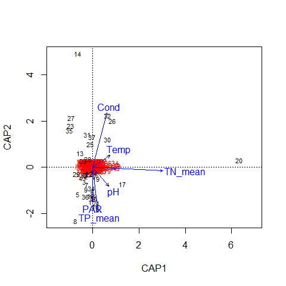

```r
RDA <- capscale(zp ~ pH + Cond + Temp + PAR + TN_mean + TP_mean, data = envi)
plot(RDA)
```

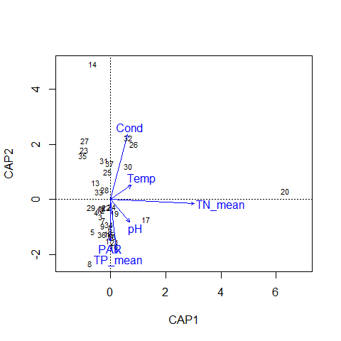

```r
plot(RDA, display = c("sites", "cn"))
```

Can manually determine how to calculate the dissimilarity among sites

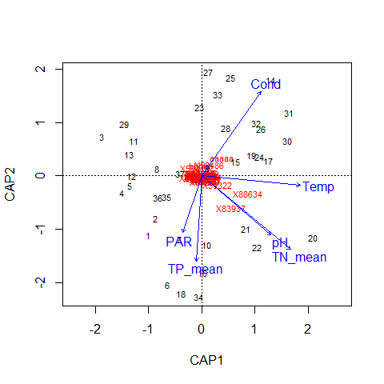

```r
zp.raw <- read.table(file = "https://raw.githubusercontent.com/OscarFHC/Multidimension/main/Data/Field_zpComm.csv",
                        sep = ",", header = TRUE)
zp <- zp.raw[,2:52]
RDA_br <- capscale(zp ~ pH + Cond + Temp + PAR + TN_mean + TP_mean, data = envi, distance = "bray")
plot(RDA_br)
```

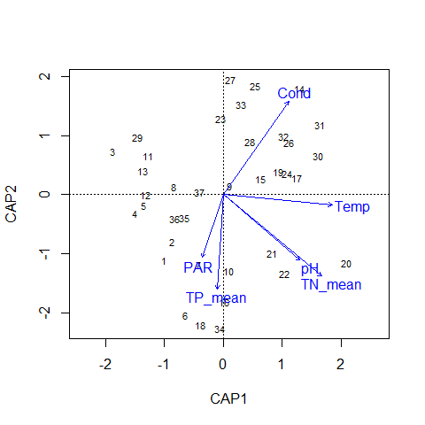

```r
plot(RDA_br, display = c("sites", "cn"))
```